# Rossmann-Analyse

## 9.3 Bagging und Random Forests

```r
###Ziel Random Forests ---> Mittlung vieler Bäume um Varianz zu reduzieren
#set.seed(1)
joinedData <- read.csv("traindata_joined_with_store_COMMA.csv")
joinedDataReduziert <- joinedData[, -c(3,19)]
train=sample(1:nrow(joinedDataReduziert), 10000)
#View(joinedDataReduziert)
sales.test=joinedDataReduziert[-train,"Sales"]
rf.sales=randomForest(Sales~.,data=joinedDataReduziert,subset=train,mtry=6,importance=TRUE,na.action=na.omit)
yhat.rf = predict(rf.sales,newdata=joinedDataReduziert[-train,])
#mean((yhat.rf-sales.test)^2)
# Evaluieren der Modellqualität
importance(rf.sales)
```

```
##                           %IncMSE IncNodePurity
## Store                       32.28      5.96e+08
## DayOfWeek                   13.52      4.38e+09
## Customers                   68.94      1.83e+10
## Open                        18.90      5.46e+09
## Promo                       43.45      2.69e+09
## StateHoliday                 0.00      0.00e+00
## SchoolHoliday               -0.72      1.04e+08
## StoreType                   51.52      6.51e+08
## Assortment                  29.77      2.74e+08
## CompetitionDistance         55.98      1.10e+09
## CompetitionOpenSinceMonth   26.41      3.95e+08
## CompetitionOpenSinceYear    35.89      4.91e+08
## Promo2                       0.00      0.00e+00
## Promo2SinceWeek             34.02      4.79e+08
## Promo2SinceYear             28.55      3.87e+08
## PromoInterval               20.96      1.69e+08
```

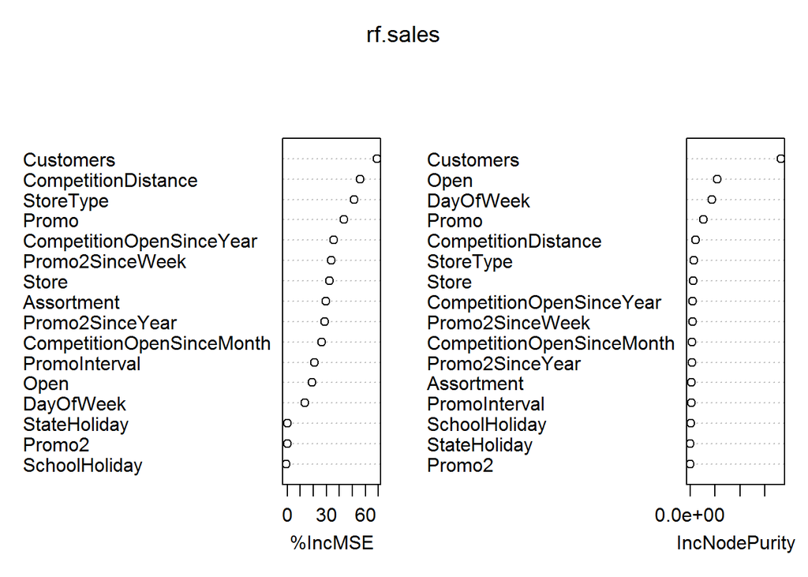

```r
varImpPlot(rf.sales)
```

**Ergebnis:** Die erste Grafik zeigt, dass, wenn einer Variablen Werte durch zufällige Permutation zugewiesen wird, um wie viel sich der durchschnittliche Fehler (MSE) erhöhen wird. Das bedeutet, wählen wir zufällig eine Kundenanzahl aus, steigt der MSE automatisch um ca. 70 Prozent. Auf der anderen Seite wird die Knotenreinheit durch den Gini-Index gemessen, welcher der Unterschied zwischen RSS vor und nach der Aufteilung auf dieser Variablen ist. Der GINI-index misst den durchschnittlichen Gewinn an Reinheit, durch Teilungen einer gegebenen Variablen. Wenn die Variable nützlich ist, tendiert sie dazu, gemischte markierte Knoten in reine einzelne Klassenknoten zu teilen. Wenn man eine nützliche Variable einstellt, ergibt sich eine relativ große Abnahme der mittleren Gini-Verstärkung. Das bedeutet eine sinnvolle Aufteilung ist nur nütztlich bezogen auf Customers, Open, DayOfWeek und Promo.

## 9.4 Boosting

```r
### kleine Bäume erstellen, jeder Baum lernt aus den Fehlern des vorherigen
#set.seed(14)
boost.train=sample(1:nrow(joinedData), 10000)
boost.joinedData=gbm(Sales~.-StoreCheck-Open-Date,data=joinedData[boost.train,],distribution="gaussian",
                     n.trees=5000,interaction.depth=4,shrinkage=0.01)
```

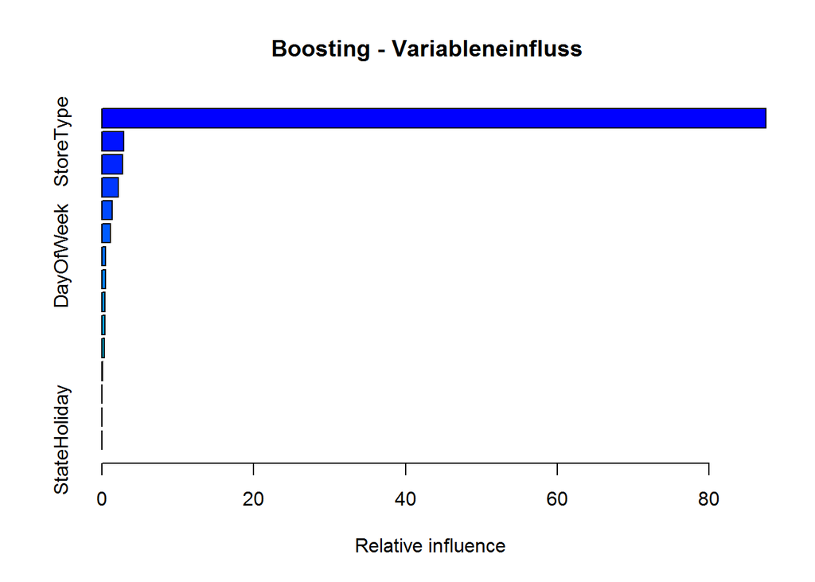

```
##                                                 var  rel.inf
## Customers                                 Customers 87.49005
## StoreType                                 StoreType  2.90910
## Promo                                         Promo  2.74081
## CompetitionDistance             CompetitionDistance  2.13440
## Assortment                               Assortment  1.39333
## Store                                         Store  1.09412
## DayOfWeek                                 DayOfWeek  0.52782
## CompetitionOpenSinceYear   CompetitionOpenSinceYear  0.47213
## Promo2SinceYear                     Promo2SinceYear  0.41413
## Promo2SinceWeek                     Promo2SinceWeek  0.41049
## CompetitionOpenSinceMonth CompetitionOpenSinceMonth  0.34157
## PromoInterval                         PromoInterval  0.05339
## SchoolHoliday                         SchoolHoliday  0.01573
## Promo2                                       Promo2  0.00293
## StateHoliday                           StateHoliday  0.00000
```

```r
#Variable importance plot
summary(boost.joinedData, main="Boosting - Variableneinfluss ") #Customer am höchsten
```

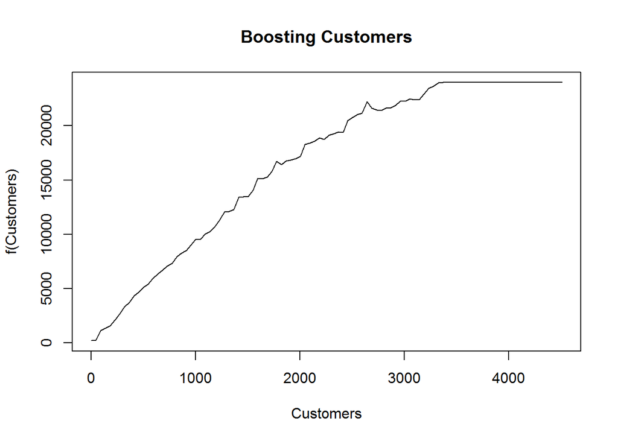

```r
#Partial dependance plots
plot(boost.joinedData, i="Customers", main="Boosting Customers")
```

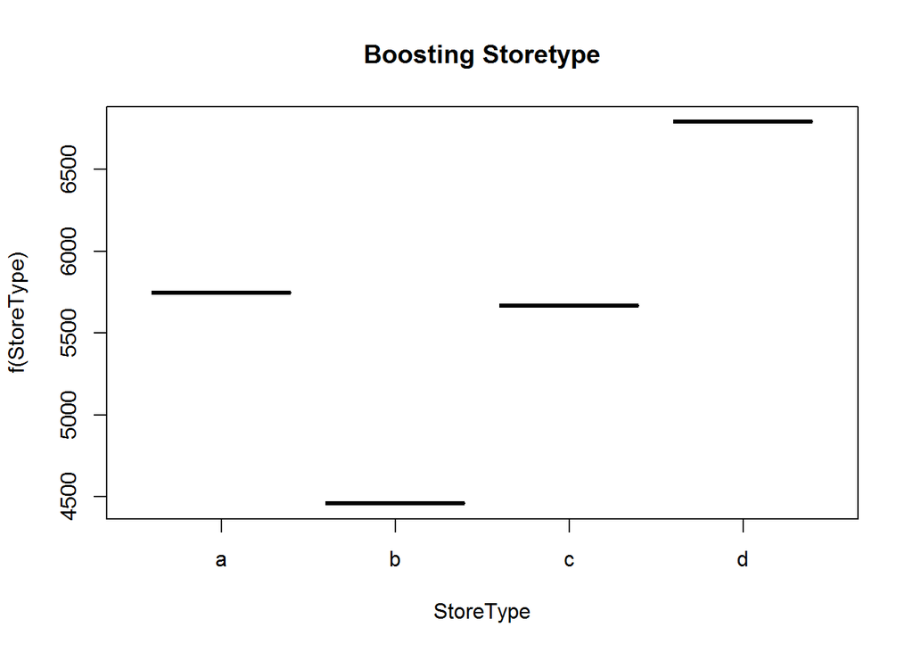

```r
plot(boost.joinedData, i="StoreType", main="Boosting Storetype")
```

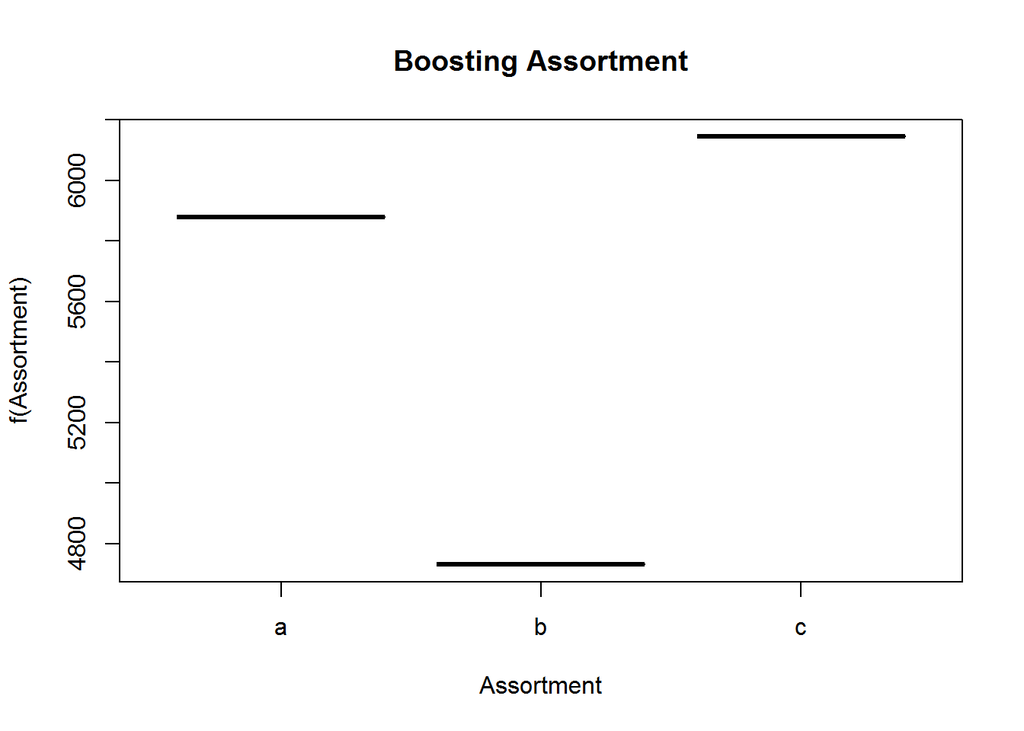

```r
plot(boost.joinedData, i="Assortment", main="Boosting Assortment")
```

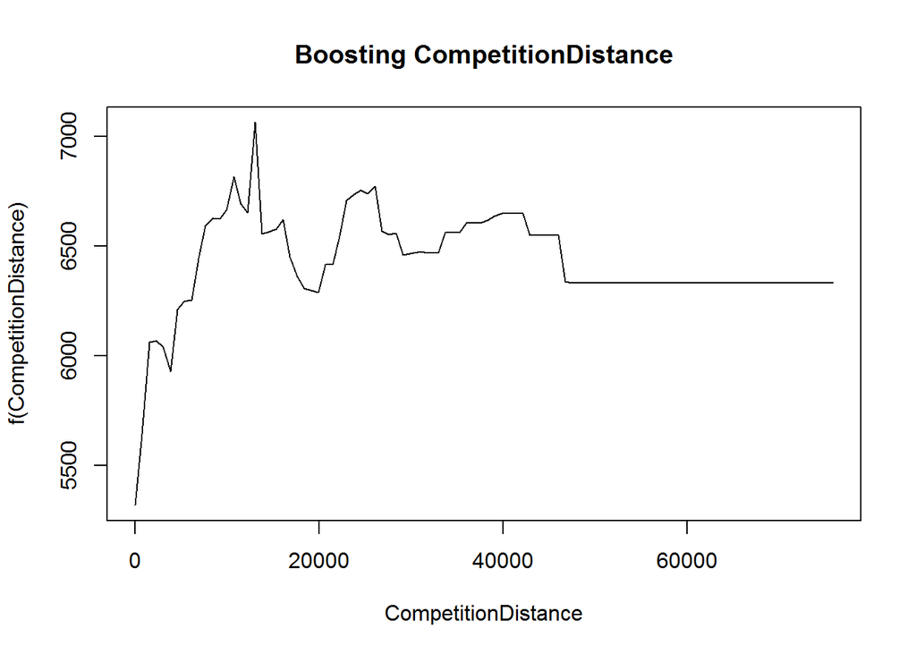

```r
plot(boost.joinedData, i="CompetitionDistance", main="Boosting CompetitionDistance")
```

**Ergebnis:** Die Graphiken zeigen den Einfluss von den wichtigsten Eingabevariablen auf Sales (f(Customers…) = Sales. In der letzten Graphik sehen wir den Einfluss der Distanz zum nächsten Konkurenten auf die Vorhersage von Sales. Eine naher Konkurent hat im ersten Anschein eigentlich negativen Einfluss auf den Umsatz (Sales), aber dies könnte auch andererseits dahingehend gedeutet werden, dass viele Konkurenten in Ballungsgebieten eine Vielzahl von Konsumenten befriedigen können.

# 10. Hauptkomponentenanalyse

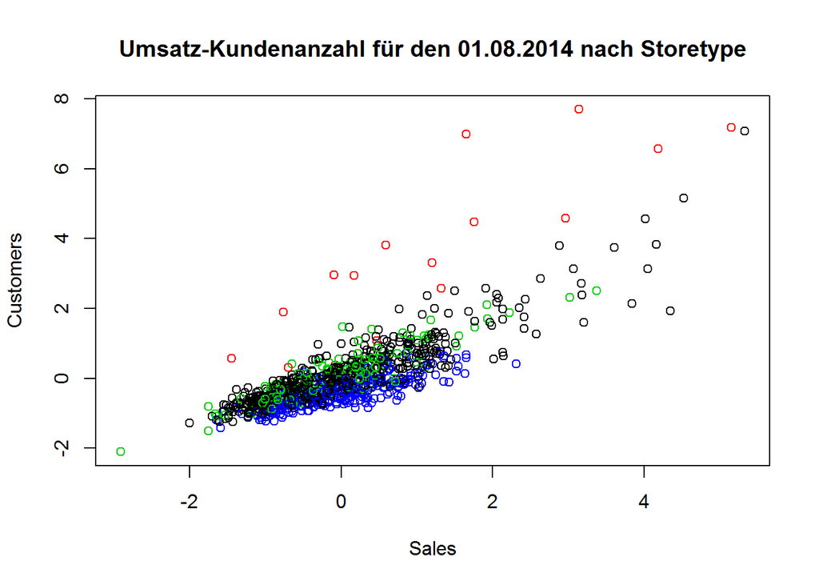

```r
# Skalieren der Daten für einen besseren Vergleich mit der PCA-Visualisierung
zeitraum_2014_1_tag <- joinedData[joinedData$Date=="01.08.2014" , ]
#Normalisierung der Spalten Customer und Sales
joinedDataReduziert2 <- zeitraum_2014_1_tag[, c(4,5,10)]
joinedDataReduziert3 <- zeitraum_2014_1_tag[, c(4,5)]
zeitraum_2014_s <- as.data.frame(scale(joinedDataReduziert3))

#View(zeitraum_2014_s)

# Rossmann Daten Zeitraum 2014 mit Klassen-Informationen (farblich)
plot(zeitraum_2014_s, col=joinedDataReduziert2$StoreType, main = "Umsatz-Kundenanzahl für den 01.08.2014 nach Storetype")
```

```r
#plot(zeitraum_2014_s)

    # mit Label
    sales_pca <- prcomp(joinedDataReduziert3, scale = TRUE)
    sales_pca
```

```
## Standard deviations:
## [1] 1.345 0.438
##
## Rotation:
##             PC1    PC2
## Sales     0.707  0.707
## Customers 0.707 -0.707
```

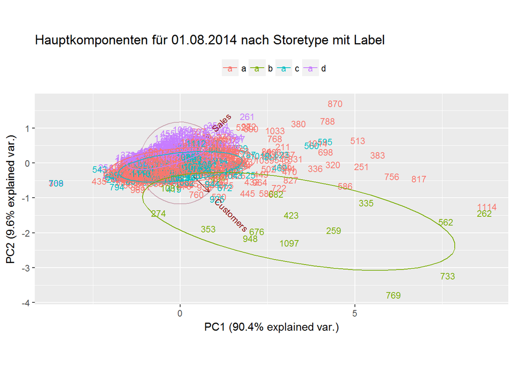

```r
    g <- ggbiplot(sales_pca, scale = 0,
                  groups = joinedDataReduziert2$StoreType, ellipse = TRUE,
                  circle = TRUE, labels = zeitraum_2014_1_tag$Store)
    g <- g + scale_color_discrete(name = '')
    g <- g + theme(legend.direction = 'horizontal',
                   legend.position = 'top')+ ggtitle("Hauptkomponenten für 01.08.2014 nach Storetype mit Label")

    print(g)
```

```r
    # ohne Label
    sales_pca <- prcomp(joinedDataReduziert3, scale = TRUE)
    sales_pca
```

```
## Standard deviations:
## [1] 1.345 0.438
##
## Rotation:
##             PC1    PC2
## Sales     0.707  0.707
## Customers 0.707 -0.707
```

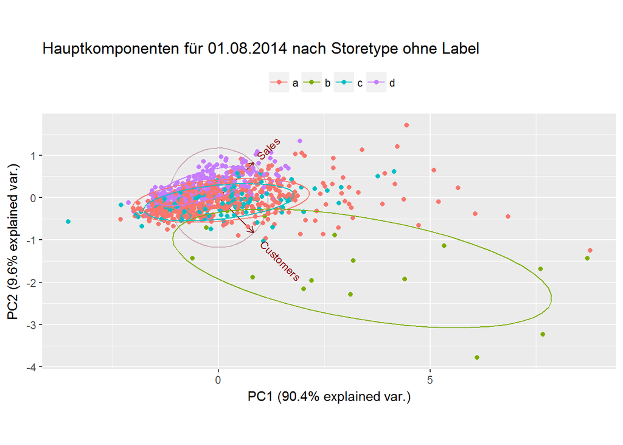

```r
    g <- ggbiplot(sales_pca, scale = 0,
                  groups = joinedDataReduziert2$StoreType, ellipse = TRUE,
                  circle = TRUE)
    g <- g + scale_color_discrete(name = '')
    g <- g + theme(legend.direction = 'horizontal',
                   legend.position = 'top')+ ggtitle("Hauptkomponenten für 01.08.2014 nach Storetype ohne Label")

    print(g)
```